# Marginální efekty v R

20. dubna 2021

## Co jsou marginální efekty?

## Motivační příklad

- Otázka: *Jak souvisí volební účast s věkem a dosaženým vzděláním?*
- Data z European Social Survey, 8. vlna
- 3 proměnné:
  - Deklarovaná účast v posledních parlamentních volbách (`vote`)
  - Věk respondenta (`age`)
  - Nejvyšší dosažené vzdělání (`education`)
- Zdánlivě jednoduchý úkol, ale…

## Motivační příklad

- Základní model:

\[ vote = age + education + \epsilon_{norm} \] - Ale vote je binární proměnná:

\[ logit(vote) = age + education + \epsilon_{binom} \] - Ale vztah mezi vol. účastí a věkem nemusí být lineární:

\[ logit(vote) = age + age^2 + education + \epsilon_{binom} \] - Ale vztah mezi vol. účastí a věkem se může lišit podle vzdělání:

\[ logit(vote) = age + age^2 + education + age*education + \\ age^2 * education + \epsilon_{binom} \]

## Motivační příklad

- Co se dá vyčíst z téhle tabulky?
  - Nic moc.
- Závislá proměnná v logitech
- Věk má kvadratický člen
- 6 interkačních členů

| **Characteristic** | **log(OR)**<sup>1</sup> | **95% CI**<sup>1</sup> | **p-value** |
| --- | --- | --- | --- |
| age |  |  |  |
| age | 30 | 18, 44 | <0.001 |
| age² | -2.7 | -13, 7.8 | 0.6 |
| education |  |  |  |
| Základní | — | — |  |
| Střední bez M | 0.43 | 0.11, 0.76 | 0.009 |
| Střední s M | 1.1 | 0.75, 1.4 | <0.001 |
| Vysokoškolské | 1.8 | 1.4, 2.2 | <0.001 |
| NA * education |  |  |  |
| age * Střední bez M | 8.8 | -7.7, 25 | 0.3 |
| age² * Střední bez M | -2.8 | -17, 12 | 0.7 |
| age * Střední s M | -7.1 | -23, 7.7 | 0.4 |
| age² * Střední s M | -4.8 | -19, 9.2 | 0.5 |
| age * Vysokoškolské | -0.06 | -20, 20 | >0.9 |
| age² * Vysokoškolské | -4.2 | -25, 18 | 0.7 |

<sup>*1*</sup> OR = Odds Ratio, CI = Confidence Interval

## Motivační příklad

- Naštěstí nemusíme spoléhat pouze na regresní koeficienty
- Alternativním řešením jsou marginální efekty
- Marginální efekt:
  - predikovaná hodnota závislé proměnné `y` v závilosti a nezávislé proměnné `x` (zatímco jsou hodnoty ostatních nezávislých proměnných drženy konstantní)
  - Alternativně: Efekt nezávislé proměnné `x` na závislou proměnnou `y`, pokud kontrolujeme pro ostatní proměnné

## Co jsou marginální efekty?

- Pokud vytvoříme model

```r
mod1 = glm(vote ~ age, family = "binomial", data = ess)
```

- Můžeme spočítat predikovanou pravděpodobnost `vote=1` v závislosti na konkrétních hodnotách `age`:

| Age | Predicted prob. | 95% CI - lower | 95% CI - higher |
| --- | --- | --- | --- |
| 15 | 36% | 31% | 40% |
| 25 | 42% | 38% | 46% |
| 35 | 49% | 46% | 52% |
| 45 | 56% | 54% | 58% |
| 55 | 62% | 60% | 65% |
| 65 | 69% | 66% | 72% |

## Co jsou marginální efekty?

Predikované pravděpodobnosti můžeme zakreslit do grafu:

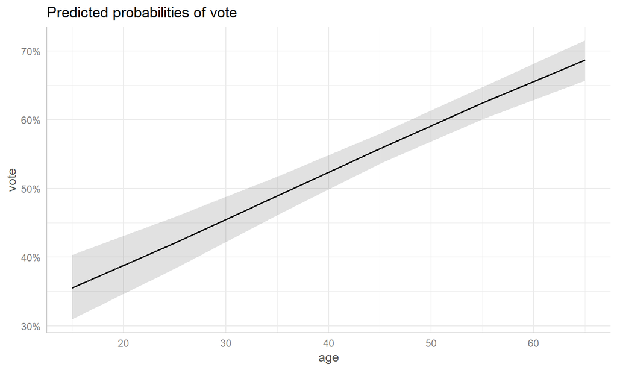

## Co jsou marginální efekty?

- Pokud má model více než 1 prediktor:

```r
mod2 = glm(vote ~ age + education,
        family = "binomial", data = ess)
```

- Můžeme spočítat predikovanou pravděpodobnost v závislosti na více prediktorech:

| Age | Predicted prob. | 95% CI - lower | 95% CI - higher | group |
| --- | --- | --- | --- | --- |
| 15 | 15% | 11% | 20% | Základní |
| 15 | 23% | 19% | 28% | Střední bez M |
| 15 | 36% | 31% | 41% | Střední s M |
| 15 | 54% | 46% | 62% | Vysokoškolské |
| 55 | 44% | 38% | 49% | Základní |
| 55 | 56% | 52% | 60% | Střední bez M |
| 55 | 70% | 67% | 74% | Střední s M |
| 55 | 83% | 79% | 87% | Vysokoškolské |
| 75 | 61% | 55% | 67% | Základní |
| 75 | 73% | 68% | 77% | Střední bez M |
| 75 | 83% | 79% | 86% | Střední s M |
| 75 | 91% | 88% | 94% | Vysokoškolské |

## Co jsou marginální efekty?

- Pokud pro nějaký prediktor chceme kontrolovat, ale nezajímá nás interpretačně, můžeme ho zafixovat na nějaké rozumné hodnotě (např. průměru)

```r
mod2 = glm(vote ~ age + education,
        family = "binomial", data = ess)
```

- Dostaneme predikované hodnoty `y` v závislosti na `x`, pokud jsou ostatní prediktory konstantní:

| Age | Predicted prob.* | 95% CI - lower | 95% CI - higher |
| --- | --- | --- | --- |
| Základní | 38% | 32% | 43% |
| Střední bez M | 50% | 46% | 54% |
| Střední s M | 65% | 61% | 68% |
| Vysokoškolské | 80% | 75% | 84% |

*For people of average age

## Zpět k motivačnímu příkladu

- Místo tabulky regresních koeficientů spočítáme marginální efekty věku a dosaženého vzdělání a zaneseme na graf

| **Characteristic** | **log(OR)**<sup>1</sup> | **95% CI**<sup>1</sup> | **p-value** |
| --- | --- | --- | --- |
| age |  |  |  |
| age | 30 | 18, 44 | <0.001 |
| age² | -2.7 | -13, 7.8 | 0.6 |
| education |  |  |  |
| Základní | — | — |  |
| Střední bez M | 0.43 | 0.11, 0.76 | 0.009 |
| Střední s M | 1.1 | 0.75, 1.4 | <0.001 |
| Vysokoškolské | 1.8 | 1.4, 2.2 | <0.001 |
| NA * education |  |  |  |
| age * Střední bez M | 8.8 | -7.7, 25 | 0.3 |
| age² * Střední bez M | -2.8 | -17, 12 | 0.7 |
| age * Střední s M | -7.1 | -23, 7.7 | 0.4 |
| age² * Střední s M | -4.8 | -19, 9.2 | 0.5 |
| age * Vysokoškolské | -0.06 | -20, 20 | >0.9 |
| age² * Vysokoškolské | -4.2 | -25, 18 | 0.7 |

<sup>*1*</sup> OR = Odds Ratio, CI = Confidence Interval

## Zpět k motivačnímu příkladu

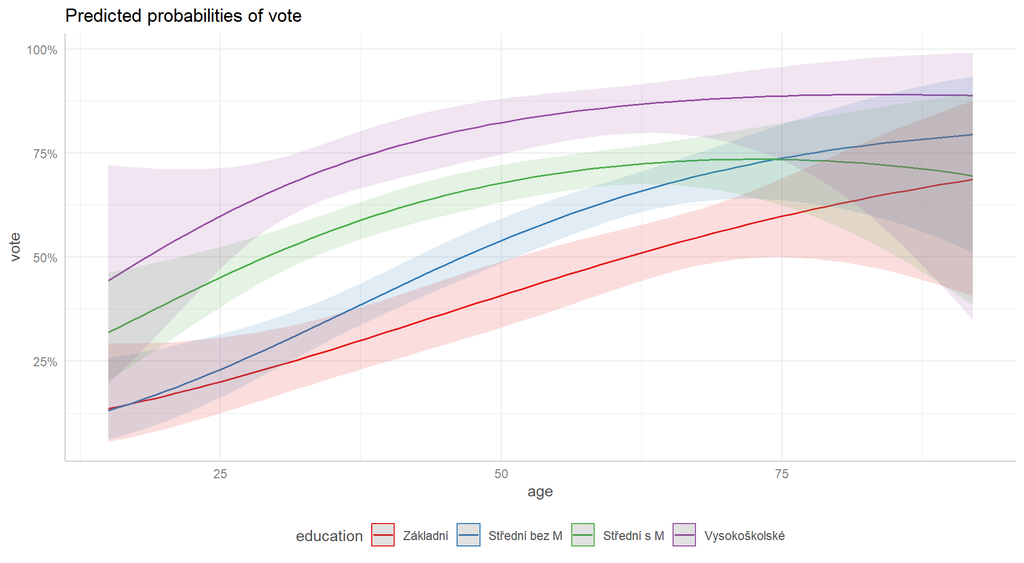

## Marginální efekty v R

## Marginální efekty v R

- Balíček `ggeffects`
- 3 primární funkce:
  - ggpredict - založeno na `stats::predict()`
  - ggeffect - založeno na `effects::effect()`
  - ggemeans - založeno na `emeans::emeans()`
- dataframe marg. efektů v tidy formátu
- pomocné funkce pro transformace
- Podporuje řadu modelů od základních (G)LM, GAM, mixed modely, bayesiánské modely, survival modely, a další

## R inteRmezzo!

## Grafy marginálních efektů jinde

- STATA - `margins` a `marginsplot` funkce
- SPSS - `EMMEANS` funkce (ale pouze pro klasickou [ANOVU](https://www.ibm.com/support/pages/will-spss-produce-marginal-effects-or-elastiticities-generalized-linear-models-such-logit-and-probit-models))?

## Závěr

- Materiály k workshopu na githubu: https://github.com/alesvomacka/workshop_ggeffects
- Podrobnější detaily ggeffects: https://strengejacke.github.io/ggeffects/